# Homework 10 Template

Author

Damini Sri Vadrevu

The goal of this week’s homework is to practice doing model validation within the tidymodels family of packages. For our analysis, I have created a dataset related to flight delays coming into Hartford in the year 2008.

These new data are provided on HuskyCT as airline_BDL.csv.

```r
library(tidyverse)
library(tidymodels)
theme_set(theme_bw())
tidymodels_prefer()

airline_BDL <- read_csv("airline_BDL.csv")
airline_BDL <- airline_BDL |>
  mutate(arr_delay_over_30 = factor(arr_delay_over_30))

airline_BDL |>
  glimpse()
```

```
Rows: 10,144
Columns: 8
$ arr_delay_over_30    <fct> TRUE, FALSE, TRUE, FALSE, FALSE, TRUE, TRUE, FALS…
$ distance             <dbl> 2298, 1050, 1050, 1050, 777, 777, 1111, 1111, 852…
$ origin               <chr> "LAS", "MCO", "MCO", "MCO", "MDW", "MDW", "TPA", …
$ month                <chr> "January", "January", "January", "January", "Janu…
$ day_of_week          <chr> "Thursday", "Thursday", "Thursday", "Thursday", "…
$ dep_delay            <dbl> 59, 3, 27, 4, 30, 33, 28, 23, 21, 3, -3, -3, 11, …
$ scheduled_dep_hour   <dbl> 16, 16, 10, 7, 19, 13, 10, 15, 18, 19, 20, 13, 21…
$ scheduled_dep_minute <dbl> 40, 45, 30, 25, 0, 50, 45, 25, 35, 55, 30, 35, 25…
```

Each of the 10144 rows in this dataset corresponds to a different flight into Bradley airport in 2008. There 8 columns (variables) described as follows:

- arr_delay_over_30: a logical variable indicating whether or not the flight’s actual arrival time was 30 or more minutes later than its scheduled arrival time. This variable will be our response variable
- distance: the distance (in miles) the flight had to travel
- origin: the airport of origin
- day_of_week: the day of the week that the flight departed
- departure_delay: the number of minutes between the flight’s scheduled departure time and actual departure time (negative means the flight departed early)
- the hour (1 means 1 am, 23 means 11 pm, etc.) of the flight’s scheduled departure.
- the minute of the flights scheduled departure

Our goal is to create a model that predicts whether or not a flight’s arrival will be delayed 30 or more minutes based on the remaining variables.

# Problem 1 [23 Points Total]

We will define four candidate models that we will be comparing. Please develop a workflow for each model that is described.

## Part A [7 Points]

A logistic regression, fit using maximum likelihood, with arr_delay_over_30 as the response and all other variables as explanatory variables.

The preprocessor should be defined using a recipe. The recipe should normalize all the numeric predictors. Moreover, it should replace any origin city that occurs in less than 1 percent of the data with an “other” category

Call this workflow workflow_A.

```r
# YOUR CODE HERE
library(tidymodels)
library(dplyr)


recipe <- recipe(arr_delay_over_30 ~ ., data = airline_BDL) |>
  step_normalize(all_numeric(), -all_outcomes()) |>
  step_other(origin, threshold = 0.01, other = "other") |>
  step_dummy(all_nominal(), -all_outcomes())

logistic_reg_model <- logistic_reg() |>
  set_engine("glm") |>
  set_mode("classification")

workflow_A <- workflow() |>
  add_recipe(recipe) |>
  add_model(logistic_reg_model)

workflow_fit <- workflow_A |>
  fit(data = airline_BDL)
```

## Part B [5 Points]

A logistic regression, fit using the lasso with a penalty = 0.1, with arr_delay_over_30 as the response and all other variables as explanatory variables. Use the same recipe as in A. Call this workflow workflow_B.

```r
# YOUR CODE HERE
library(tidymodels)
library(dplyr)
library(themis)
recipe <- recipe(arr_delay_over_30 ~ ., data = airline_BDL) |>
  step_normalize(all_numeric(), -all_outcomes()) |>
  step_other(origin, threshold = 0.01, other = "other") |>
  step_dummy(all_nominal(), -all_outcomes())

logistic_reg_lasso <- logistic_reg(penalty = 0.1, mixture = 1) |>
  set_engine("glmnet") |>
  set_mode("classification")

workflow_B <- workflow() |>
  add_recipe(recipe) |>
  add_model(logistic_reg_lasso)

workflow_fit_B <- workflow_B|>
  fit(data = airline_BDL)
```

## Part C [5 Points]

A k-nearest neighbors model, fit using k = 10, with arr_delay_over_30 as the response and all other variables as explanatory variables. Use the same recipe as in A. Call this workflow workflow_C.

```r
# YOUR CODE HERE


recipe <- recipe(arr_delay_over_30 ~ ., data = airline_BDL) |>
  step_normalize(all_numeric(), -all_outcomes()) |>
  step_other(origin, threshold = 0.01, other = "other") |>
  step_dummy(all_nominal(), -all_outcomes())

knn_spec <- nearest_neighbor(neighbors = 10) |>
  set_engine("kknn") |>
  set_mode("classification")

workflow_C <- workflow() |>
  add_recipe(recipe) |>
  add_model(knn_spec)

workflow_fit_C <- workflow_C |>
  fit(data = airline_BDL)
```

## Part D [5 Points]

A random forest model, fit using ranger, with arr_delay_over_30 as the response and all other variables as explanatory variables. Use the same recipe as in A. Call this workflow workflow_D.

```r
# YOUR CODE HERE
random_forest_spec <- rand_forest() |>
  set_engine("ranger") |>
  set_mode("classification")

workflow_D <- workflow() |>
  add_recipe(recipe) |>
  add_model(random_forest_spec)

workflow_fit_D <- workflow_D |>
  fit(data=airline_BDL)
```

# Problem 2 [25 Points Total]

Now, we will practice different data splitting strategies.

## Part A [5 Points]

First, split the data into a testing and training set with 70 percent of the data being used for training, 30 percent being used for test, and no stratification.

```r
# YOUR CODE HERE
set.seed(1)

airline_split <- airline_BDL |>
  initial_split(prop = 0.7)

airline_train <- airline_split |>
  training()

airline_test <- airline_split |>
  testing()
```

## Part B [5 Points]

From the training set, create a variable of class rset called val_set that contains test-validation split where the validation set contains 20 percent of the data in the training set.

```r
# YOUR CODE HERE
library(rsample)
set.seed(14)
val_set <- validation_split(airline_train,
                            prop = 0.20)
val_set |>
  class()
```

```
[1] "validation_split" "rset"             "tbl_df"           "tbl"
[5] "data.frame"
```

## Part C [5 Points]

From the training set, create a variable of class rset called vfold_set that contains a 5-fold cross validation split.

```r
# YOUR CODE HERE
library(rsample)

set.seed(12)

vfold_set <- airline_train |>
  vfold_cv(v = 5)

vfold_set |>
  class()
```

```
[1] "vfold_cv"   "rset"       "tbl_df"     "tbl"        "data.frame"
```

## Part D [5 Points]

From the training set, create a variable of class rset called mc_set that contains 10 random splits of the data.

```r
# YOUR CODE HERE
library(rsample)

set.seed(12)

mc_set <- airline_train |>
  mc_cv(times = 10)

mc_set |>
  class()
```

```
[1] "mc_cv"      "rset"       "tbl_df"     "tbl"        "data.frame"
```

## Part E [5 Points]

From the training set, create a variable of class rset called bootstrap_set that contains 10 bootstrap random splits of the data.

```r
# YOUR CODE HERE
library(rsample)

set.seed(12)

bootstrap_set <- airline_train |>
  bootstraps(times = 10)

bootstrap_set |>
  class()
```

```
[1] "bootstraps" "rset"       "tbl_df"     "tbl"        "data.frame"
```

# Problem 3 [37 Points Total]

We are now going to compare the performance of each in the workflows in Problem 1 using each of the validation strategies from Problem 2.

## Part A [8 Points]

Using a re-substitution strategy for the test-train split from part 2A, compare the performance of the four workflows (workflow_A, workflow_B, workflow_C, and workflow_D) defined in Problem 1. Use area under the ROC curve as the comparison metric.

```r
# YOUR CODE HERE

library(tidymodels)
library(dplyr)
library(purrr)
library(ggplot2)
library(yardstick)

workflows_tbl <- tibble(
  workflow_name = c("workflow_A", "workflow_B", "workflow_C", "workflow_D"),
  workflow_object = list(workflow_A, workflow_B, workflow_C, workflow_D))

set.seed(1)
workflows_tbl <- workflows_tbl |>
  rowwise() |>
  mutate(fits = list(fit(workflow_object,
                         airline_train)))
workflows_tbl
```

```
# A tibble: 4 × 3
# Rowwise:
  workflow_name workflow_object fits
  <chr>         <list>          <list>
1 workflow_A    <workflow>      <workflow>
2 workflow_B    <workflow>      <workflow>
3 workflow_C    <workflow>      <workflow>
4 workflow_D    <workflow>      <workflow>
```

```r
workflows_tbl <- workflows_tbl |>
  mutate(pred_class = list(predict(fits,
                                   airline_train,
                                   type = "class"))) |>
  mutate(pred_prob = list(predict(fits,
                                  airline_train,
                                  type = "prob")))

workflows_tbl <- workflows_tbl |>
  mutate(predictions = list(bind_cols(pred_class, pred_prob))) |>
  select(-c(pred_class, pred_prob))

predictions_tbl  <- workflows_tbl |>
  select(workflow_name,
         predictions) |>
  unnest(cols = c(predictions)) |>
  cbind(arr_delay_over_30 = airline_train |>
          pull(arr_delay_over_30))

predictions_tbl |> glimpse()
```

```
Rows: 28,400
Columns: 5
$ workflow_name     <chr> "workflow_A", "workflow_A", "workflow_A", "workflow_…
$ .pred_class       <fct> FALSE, FALSE, FALSE, FALSE, FALSE, TRUE, FALSE, FALS…
$ .pred_FALSE       <dbl> 9.901206e-01, 9.944455e-01, 9.898763e-01, 9.881586e-…
$ .pred_TRUE        <dbl> 0.009879434, 0.005554469, 0.010123709, 0.011841436, …
$ arr_delay_over_30 <fct> FALSE, FALSE, FALSE, FALSE, FALSE, TRUE, FALSE, FALS…
```

```r
roc_lasso <- predictions_tbl |>
  group_by(workflow_name) |>
  roc_curve(truth = arr_delay_over_30,
            .pred_TRUE,
            event_level = "second")

roc_lasso |>
  glimpse()
```

```
Rows: 13,879
Columns: 4
Groups: workflow_name [4]
$ workflow_name <chr> "workflow_A", "workflow_A", "workflow_A", "workflow_A", …
$ .threshold    <dbl> -Inf, 1.014017e-05, 1.091782e-04, 1.322330e-04, 1.630526…
$ specificity   <dbl> 0.0000000000, 0.0000000000, 0.0001639613, 0.0003279226, …
$ sensitivity   <dbl> 1, 1, 1, 1, 1, 1, 1, 1, 1, 1, 1, 1, 1, 1, 1, 1, 1, 1, 1,…
```

Which workflow performed best according to this metric?

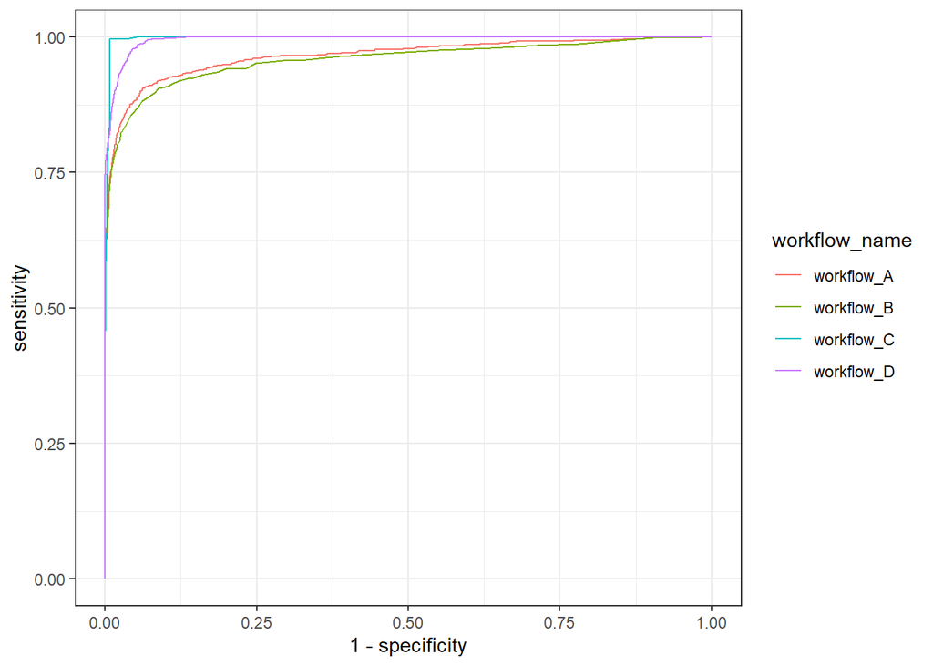

```r
roc_lasso |>
  ggplot(aes(x = 1 - specificity,
             y = sensitivity,
             color = workflow_name)) +
  geom_path()
```

Workflow C does the best job.

```r
workflows_resub <- workflows_tbl |>
  mutate(predictions = list(predict(fits,
                                    airline_train,
                                    type = "class")))

predictions_resub  <- workflows_resub |>
  select(workflow_name,
         predictions) |>
  unnest(cols = c(predictions)) |>
  cbind(arr_delay_over_30 = airline_train |>
          pull(arr_delay_over_30))

resub_performance <- predictions_resub |>
  group_by(workflow_name) |>
  accuracy(truth = arr_delay_over_30,
           estimate = .pred_class) |>
  arrange(workflow_name)

comparison_table <- resub_performance |>
  select(workflow_name) |>
  mutate(estimate_resub = resub_performance |> pull(.estimate))

comparison_table
```

```
# A tibble: 4 × 2
  workflow_name estimate_resub
  <chr>                  <dbl>
1 workflow_A             0.957
2 workflow_B             0.908
3 workflow_C             0.937
4 workflow_D             0.968
```

## Part B [7 Points]

Define a metric set consisting exclusively of the area under the ROC curve.

```r
# YOUR CODE HERE
auc_metric_set <- metric_set(roc_auc)
```

Use this metric set and the validation set from Problem 2B to compare the performance of the four workflows (workflow_A, workflow_B, workflow_C, and workflow_D) defined in Problem 1.

```r
# YOUR CODE HERE
set.seed(143)
workflows_val <- workflows_tbl |>
  mutate(fits = list(fit_resamples(workflow_object,
                                   val_set,
                                   metrics = auc_metric_set))) |>
  mutate(metrics = list(collect_metrics(fits)))
```

```
→ A | warning: glm.fit: fitted probabilities numerically 0 or 1 occurred
```

```
There were issues with some computations   A: x1
There were issues with some computations   A: x1
```

Which workflow performed best according to this metric?

```r
# YOUR CODE HERE
workflows_val |>
  select(c(workflow_name,
           metrics)) |>
  unnest(metrics) |>
  arrange(.metric)
```

```
# A tibble: 4 × 7
  workflow_name .metric .estimator  mean     n std_err .config
  <chr>         <chr>   <chr>      <dbl> <int>   <dbl> <chr>
1 workflow_A    roc_auc binary     0.944     1      NA Preprocessor1_Model1
2 workflow_B    roc_auc binary     0.960     1      NA Preprocessor1_Model1
3 workflow_C    roc_auc binary     0.743     1      NA Preprocessor1_Model1
4 workflow_D    roc_auc binary     0.942     1      NA Preprocessor1_Model1
```

```r
comparison_table <- comparison_table |>
  mutate(estimate_validation = workflows_val |>
  select(c(workflow_name,
           metrics)) |>
  unnest(metrics) |>
  arrange(.metric) |> pull(mean))
```

Workflow b performed the best.

## Part C [7 Points]

Use the same metric set from above and vfold_set from Problem 2C to compare the performance of the four workflows (workflow_A, workflow_B, workflow_C, and workflow_D) defined in Problem 1.

```r
# YOUR CODE HERE
workflows_vfold <- workflows_tbl |>
  mutate(fits = list(fit_resamples(workflow_object,
                                         vfold_set,
                                         metrics = auc_metric_set))) |>
  mutate(metrics = list(collect_metrics(fits)))
```

```
→ A | warning: glm.fit: fitted probabilities numerically 0 or 1 occurred
```

```
There were issues with some computations   A: x1
```

```
There were issues with some computations   A: x5
```

Which workflow performed worst according to this metric?

```r
# YOUR CODE HERE
workflows_vfold_results <- workflows_vfold |>
  select(workflow_name,
         metrics) |>
  arrange(workflow_name)

workflows_vfold_results|>
  unnest()
```

```
# A tibble: 4 × 7
  workflow_name .metric .estimator  mean     n std_err .config
  <chr>         <chr>   <chr>      <dbl> <int>   <dbl> <chr>
1 workflow_A    roc_auc binary     0.961     5 0.00315 Preprocessor1_Model1
2 workflow_B    roc_auc binary     0.958     5 0.00247 Preprocessor1_Model1
3 workflow_C    roc_auc binary     0.820     5 0.00604 Preprocessor1_Model1
4 workflow_D    roc_auc binary     0.954     5 0.00182 Preprocessor1_Model1
```

```r
comparison_table <- comparison_table |>
  mutate(estimate_vfold = workflows_vfold_results|> unnest() |> pull(mean))
comparison_table
```

```
# A tibble: 4 × 4
  workflow_name estimate_resub estimate_validation estimate_vfold
  <chr>                  <dbl>               <dbl>          <dbl>
1 workflow_A             0.957               0.944          0.961
2 workflow_B             0.908               0.960          0.958
3 workflow_C             0.937               0.743          0.820
4 workflow_D             0.968               0.942          0.954
```

## Part D [10 Points]

Use the same metric set from above and mc_set from Problem 2D to compare the performance of the four workflows (workflow_A, workflow_B, workflow_C, and workflow_D) defined in Problem 1.

```r
# YOUR CODE HERE
workflows_mc <- workflows_tbl |>
  mutate(fits = list(fit_resamples(workflow_object,
                                         mc_set,
                                         metrics = auc_metric_set))) |>
  mutate(metrics = list(collect_metrics(fits)))
```

```
→ A | warning: glm.fit: fitted probabilities numerically 0 or 1 occurred
```

```
There were issues with some computations   A: x1
```

```
There were issues with some computations   A: x8
```

```
There were issues with some computations   A: x10
```

According to the results, is the difference between the performance of workflow A (logistic regression) and workflow D (random forest) statistically significant?

```r
# YOUR CODE HERE
 workflows_mc |>
  select(workflow_name,
         metrics) |>
  unnest(metrics)
```

```
# A tibble: 4 × 7
  workflow_name .metric .estimator  mean     n std_err .config
  <chr>         <chr>   <chr>      <dbl> <int>   <dbl> <chr>
1 workflow_A    roc_auc binary     0.967    10 0.00276 Preprocessor1_Model1
2 workflow_B    roc_auc binary     0.963    10 0.00302 Preprocessor1_Model1
3 workflow_C    roc_auc binary     0.812    10 0.00433 Preprocessor1_Model1
4 workflow_D    roc_auc binary     0.959    10 0.00260 Preprocessor1_Model1
```

```r
comparison_table <- comparison_table |>
  mutate(estimate_mc = workflows_mc |>
  select(workflow_name,
         metrics) |>
  unnest(metrics)  |> pull(mean))
```

## Part E [5 Points]

Use the same metric set from above and bootstrap_set from Problem 2E to compare the performance of the four workflows (workflow_A, workflow_B, workflow_C, and workflow_D) defined in Problem 1.

```r
# YOUR CODE HERE
workflows_bootstrap <- workflows_tbl |>
  mutate(fits = list(fit_resamples(workflow_object,
                                         bootstrap_set,
                                         metrics = auc_metric_set))) |>
  mutate(metrics = list(collect_metrics(fits)))
```

```
→ A | warning: glm.fit: fitted probabilities numerically 0 or 1 occurred
```

```
There were issues with some computations   A: x1
```

```
There were issues with some computations   A: x6
```

```
There were issues with some computations   A: x10
```

Which workflow’s performance estimator has the highest standard error?

```r
# YOUR CODE HERE
workflows_bootstrap |>
  select(workflow_name,
         metrics) |>
  unnest(metrics)
```

```
# A tibble: 4 × 7
  workflow_name .metric .estimator  mean     n std_err .config
  <chr>         <chr>   <chr>      <dbl> <int>   <dbl> <chr>
1 workflow_A    roc_auc binary     0.959    10 0.00209 Preprocessor1_Model1
2 workflow_B    roc_auc binary     0.960    10 0.00184 Preprocessor1_Model1
3 workflow_C    roc_auc binary     0.790    10 0.00509 Preprocessor1_Model1
4 workflow_D    roc_auc binary     0.952    10 0.00224 Preprocessor1_Model1
```

```r
comparison_table <- comparison_table |>
  mutate(estimate_bootstrap = workflows_bootstrap |>
  select(workflow_name,
         metrics) |>
  unnest(metrics) |> pull(mean))

comparison_table
```

```
# A tibble: 4 × 6
  workflow_name estimate_resub estimate_validation estimate_vfold estimate_mc
  <chr>                  <dbl>               <dbl>          <dbl>       <dbl>
1 workflow_A             0.957               0.944          0.961       0.967
2 workflow_B             0.908               0.960          0.958       0.963
3 workflow_C             0.937               0.743          0.820       0.812
4 workflow_D             0.968               0.942          0.954       0.959
# ℹ 1 more variable: estimate_bootstrap <dbl>
```

Workload C Has highest Standard error.

# Problem 4 [15 Points Total]

## Part A [9 Points]

Create plot with geom_col(position = “dodge”) to compare the estimated predictive performance of all four models based on the different validation strategies discussed above:

- re-substitution,
- a validation set,
- vfold cross validation,
- Monte Carlo cross validation, and
- bootstrap cross validation.

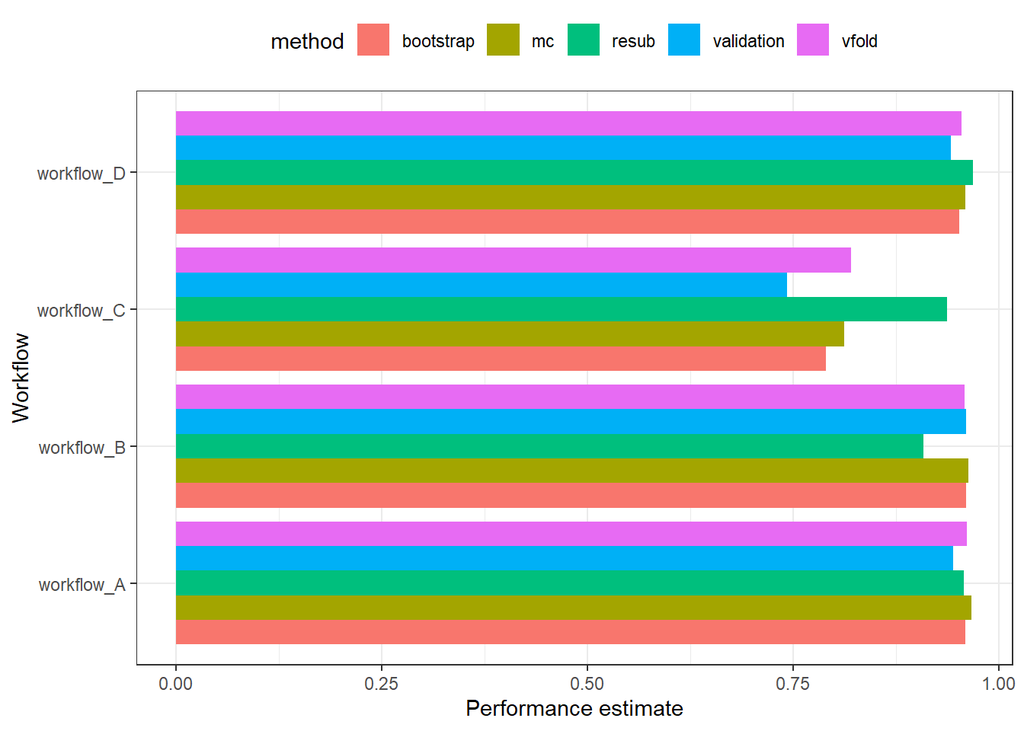

```r
# YOUR CODE HERE
comparison_table|>
pivot_longer(
    cols = starts_with("estimate"),
    names_to = "method",
    values_to = "performance_estimate"
  )|>mutate(method = gsub("estimate_", "", method))|>
  ggplot( aes(x = workflow_name, y = performance_estimate, fill = method)) +
  geom_col(position = position_dodge()) +
  coord_flip()+
  labs(y = "Performance estimate", x = "Workflow") +
  theme(legend.position = "top")
```

Comment on the the implications of this figure. Which validation methods seem to mostly agree? Which tend to differ? For workflows do they differ? Why do you think these differences occur?

Certain validation methods might be more suitable for the underlying data distribution

## Part B [6 Points]

Evaluate the predictive performance on the held-out test data.

```r
# YOUR CODE HERE


airline_test <- airline_split|>
  testing()

workflows_tbl_predictions <- workflows_tbl |>
  mutate(pred_class = list(predict(fits,
                                   airline_test,
                                   type = "class"))) |>
  mutate(pred_prob = list(predict(fits,
                                  airline_test,
                                  type = "prob")))

workflows_tbl_predictions <- workflows_tbl_predictions |>
  mutate(predictions = list(bind_cols(pred_class, pred_prob))) |>
  select(-c(pred_class, pred_prob))

predictions_tbl  <- workflows_tbl_predictions |>
  select(workflow_name,
         predictions) |>
  unnest(cols = c(predictions)) |>
  cbind(arr_delay_over_30 = airline_test |>
          pull(arr_delay_over_30))

test_performance <- predictions_tbl |>
  group_by(workflow_name) |>
  accuracy(truth = arr_delay_over_30,
           estimate = .pred_class) |>
  arrange(workflow_name)

test_performance
```

```
# A tibble: 4 × 4
  workflow_name .metric  .estimator .estimate
  <chr>         <chr>    <chr>          <dbl>
1 workflow_A    accuracy binary         0.963
2 workflow_B    accuracy binary         0.908
3 workflow_C    accuracy binary         0.913
4 workflow_D    accuracy binary         0.961
```

Which validation methods seemed to do a good job on estimating performance on the test set? Which ones did poorly?

Workflow A does best job